# Introduction

This is the final project for the Introduction to Open Data Science -course. The project consists of choosing the dataset, wrangling it for the analysis, performing the analysis and commenting on the results.

# Choosing the dataset.

Since I am a scientist myself, I chose a dataset that has to do with science. It’s called Tiedebarometri (engl. science barometer) and it asks about Finnish people interests and activity in science. You can find out more about the dataset [here](https://services.fsd.uta.fi/catalogue/FSD3137), but unfortunately at this point the data description is only in Finnish. But not to worry, I will describe all the variables used in this project also in English.

(In case you are interested, on the website you can find a lot of other interesting datasets as well that can be downloaded if you are a student or staff in some Finnish university.)

By looking at my data wrangling code you can find out what I did to my data set prior to the analysis. I decided to keep only the variables used in the analysis in the dataset, because it is simple to handle a dataset with 5 variables instead of more than 100.

# Description of the SCIENCE-dataset

```r
#Read the data into RStudio
setwd("C:/Users/Paula/Documents/GitHub/IODS-project/IODS-final/IODS-final")
SCIENCE<-read.csv("SCIENCE.csv",header=T)
```

```r
dim(SCIENCE)
```

```
## [1] 980   5
```

```r
str(SCIENCE)
```

```
## 'data.frame':    980 obs. of  5 variables:
##  $ sex       : int  1 1 1 2 1 1 1 1 1 2 ...
##  $ age       : int  3 3 4 4 3 3 4 6 1 2 ...
##  $ townsize  : int  5 5 3 3 5 5 5 2 5 5 ...
##  $ edu       : int  5 3 3 3 6 6 2 4 3 5 ...
##  $ interested: int  0 1 0 1 1 1 1 0 1 0 ...
```

The dataset has 980 observations and 5 variables:

- sex (male = 1, female = 2)
- age (18-25 years = 1, 26-35 = 2, 36-45 = 3, 46-55 = 4, 56-65 = 5, >65 = 6)
- townsize (<4000 inhabitants = 1, 4000-8000 = 2, 8000-30000 = 3, 30000-80000 = 4, >80000 = 5)
- edu (no professional education = 1, a short course or a short school for a profession = 2, vocational school = 3, post-secondary education = 4, polytechnic education = 5, university level education = 6)
- interested (not-interested in science = 0, interested in science = 1)

By looking at the structure of the variables we can see that they are all integer. *Sex* and *interested* are binary variables and rest of them are ordinal, which means that they are discrete but their different possible values can be put in clear order.

# Hypotesis

I am trying to find out variables that could explain whether the people are interested in science or not. My hypothesis is that maybe men are more interested in science than women, older people are more interested than young people, people in bigger towns are more interested than the ones living in smaller towns, and people with upper level education are more interested than lower level education.

# Pre-analysis

```r
# Call packages needed for the analysis from the library
library(tidyr)
library(ggplot2)
library(dplyr)
library(GGally)
library(corrplot)
library("FactoMineR")
```

Lets’s first take a look at the correlations of between the variables in order to get the initial idea of their relationships.

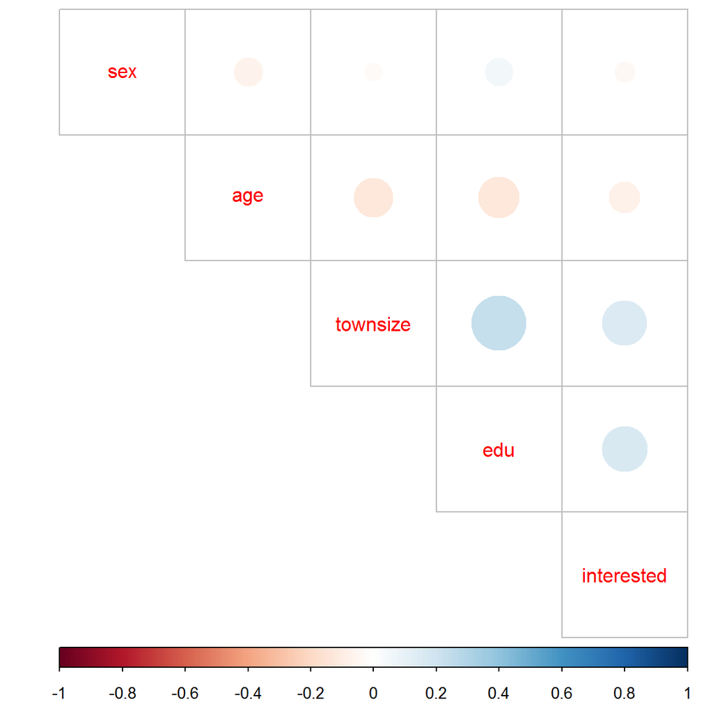

*Figure 1.1 Correlations between the variables.*

```r
#Calculate the correlation matrix and round it
cor_matrix<-cor(SCIENCE)

#Visualize the correlation matrix
corrplot(cor_matrix, method="circle", type="upper",cl.pos="b",tl.pos="d",tl.cex=1.0)
```

We can see that there is some positive correlation between townsize and education, and that they seem to be a little bit positively correlated with the variable of interest as well. Age seems to correlate negatively a little bit with townsize and education, that is: The older you are, in smaller town you live and less education you have. The negative correlation between age and education seems weird to me, but I guess it could have something to do with the fact that before high level education wasn’t as accessible to people as it is today.

To look better the distributions of each variable, I created barplots of them.

```r
#Use gather() to gather columns into key-value pairs and then glimpse() at the resulting data
gather(SCIENCE) %>% glimpse
```

```
## Observations: 4,900
## Variables: 2
## $ key   <chr> "sex", "sex", "sex", "sex", "sex", "sex", "sex", "sex", ...
## $ value <int> 1, 1, 1, 2, 1, 1, 1, 1, 1, 2, 2, 2, 2, 2, 2, 2, 2, 2, 2,...
```

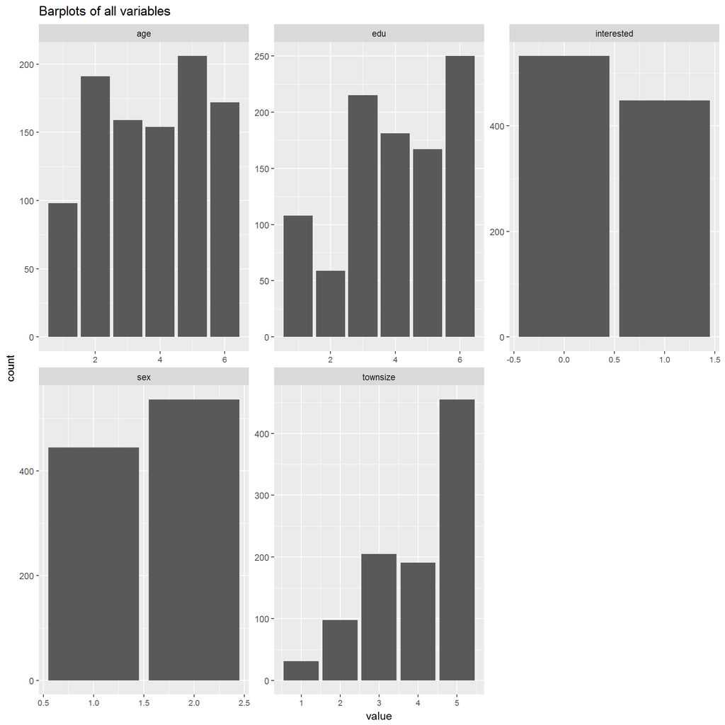

*Figure 1.2 Bar plots of the variables.*

```r
#Draw a bar plot of each variable
gather(SCIENCE) %>% ggplot(aes(value)) + facet_wrap("key", scales = "free") + geom_bar() + theme(axis.text.x = element_text(size = 8)) +ggtitle("Barplots of all variables")
```

We can see that more people live in big towns than in small towns. More people have high level education than low level education. There are slightly more women than men among the participants, and slightly more are not interested in science than are interested. Distribution of age seems pretty much uniform (if we look at the “big picture”) exept that there are less participant from the lowest agegroup than from any other.

# Logistic Regression Analysis

```r
##Starting of the analysis
attach(SCIENCE)
logreg1<-glm(interested~edu,family="binomial")
summary(logreg1)
```

```
##
## Call:
## glm(formula = interested ~ edu, family = "binomial")
##
## Deviance Residuals:
##     Min       1Q   Median       3Q      Max
## -1.2749  -1.1022  -0.8657   1.1675   1.5252
##
## Coefficients:
##             Estimate Std. Error z value Pr(>|z|)
## (Intercept) -0.99135    0.17812  -5.566 2.61e-08 ***
## edu          0.20295    0.04075   4.981 6.34e-07 ***
## ---
## Signif. codes:  0 '***' 0.001 '**' 0.01 '*' 0.05 '.' 0.1 ' ' 1
##
## (Dispersion parameter for binomial family taken to be 1)
##
##     Null deviance: 1351.4  on 979  degrees of freedom
## Residual deviance: 1325.8  on 978  degrees of freedom
## AIC: 1329.8
##
## Number of Fisher Scoring iterations: 4
```

```r
chisq.test(age,edu)
```

```
##
##  Pearson's Chi-squared test
##
## data:  age and edu
## X-squared = 231.23, df = 25, p-value < 2.2e-16
```

```r
chisq.test(interested,sex)
```

```
##
##  Pearson's Chi-squared test with Yates' continuity correction
##
## data:  interested and sex
## X-squared = 0.94052, df = 1, p-value = 0.3321
```

```r
2+2
```

```
## [1] 4
```